# K-Means Interactive on *mtcars* Dataset

Michael R. D’Amour

Friday, November 21, 2014

### K-Means Interactive

With K-Means Interactive, a Shiny application, you can watch the standard R K-Means clustering algorithm operate in real time. The algorithm is run on the Motor Trend *mtcars* data base with all variables available for plotting and the ability to choose the number of clusters.

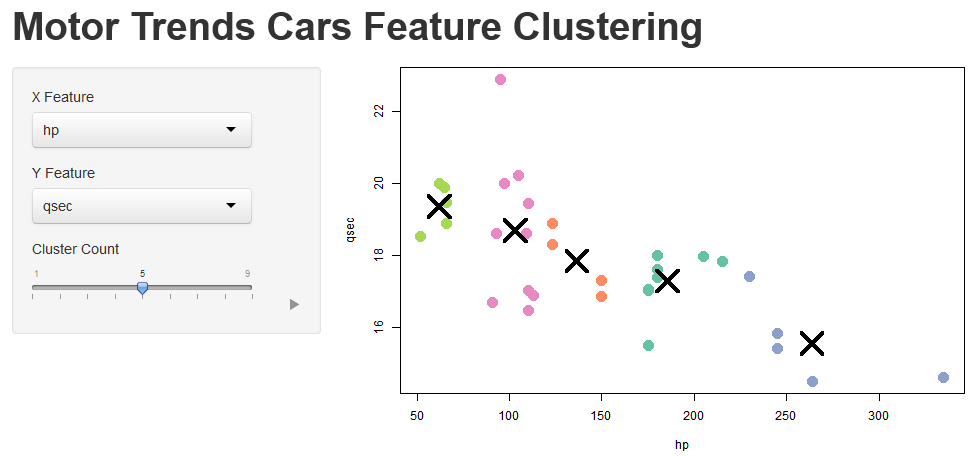

**Run K-Means Interactive at** *https://mikedamour.shinyapps.io/ShinyProject*  
**See the project repo at** *https://github.com/mikedamour/KmeansInteractive*

### Interacting with K-Means

The K-Means app lets you

- Choose any of the R-builtin *mtcars* dataset for your X or Y Feature using pull-down menus.
- Choose the number of clusters you would like to have fit on the scatterplot data via slider.
- As you choose features and cluster numbers, the data will update immediately. K-means chooses the clusters and marks their centers prominently.
- Press the slider arrow to sequence through clustering selections 1 to 9.

The app also provides an interesting visualization of the relationship of automobile performance to various car features.

**Attribution**  
This application is based on the Iris Data k-means template by Joe Cheng joe@rstudio.com at the RStudio Gallery site.